# Cwong Assign2

Calvin Wong

2/7/2019

ASSIGNMENT 2

IS 605 FUNDAMENTALS OF COMPUTATIONAL MATHEMATICS - 2015

1. Problem set 1
1. Show that A^TA ≠ AA^T in general. (Proof and demonstration.)

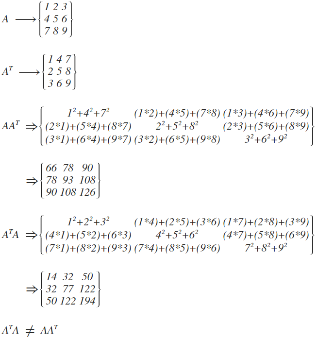

2. For a special type of square matrix A, we get A^TA = AA^T . Under what conditions could this be true? (Hint: The Identity matrix I is an example of such a matrix).

A symmetric matrix is a square matrix that is equal to its transpose. Formally, where A = A^T.

2. Problem set 2 Matrix factorization is a very important problem. There are supercomputers built just to do matrix factorizations. Every second you are on an airplane, matrices are being factorized. Radars that track flights use a technique called Kalman filtering. At the heart of Kalman Filtering is a Matrix Factorization operation. Kalman Filters are solving linear systems of equations when they track your flight using radars.

Write an R function to factorize a square matrix A into LU or LDU, whichever you prefer. Please submit your response in an R Markdown document using our class naming convention, E.g. LFulton_Assignment2_PS2.png

You don’t have to worry about permuting rows of A and you can assume that A is less than 5x5, if you need to hard-code any variables in your code. If you doing the entire assignment in R, then please submit only one markdown document for both the problems.

```r
LU <- function(M)
{
r = dim(M)[1]
U = M
L = matrix(0,r,r) #squaring

  for (x in 1:r)
  {
  L[x,x] = 1
  }

  for (p in 1:(r-1))
  {
    for (i in p:(r-1))
    {
    mlt = round(((U[i+1,p])/(U[p,p])), digits = 2)
    L[i+1,p] = mlt
      for (j in p:r)
      {
      U[i+1,j] = U[i+1,j] - U[p,j] * mlt
      }
    }
  }
LU = list("Lower" = L,"Upper" = U)
return(LU)
}

A = matrix(c(1,4,-3,-2,8,5,3,4,7), nrow = 3, ncol = 3, byrow = TRUE)
LU(A)
```

```
## $Lower
##      [,1] [,2] [,3]
## [1,]    1  0.0    0
## [2,]   -2  1.0    0
## [3,]    3 -0.5    1
##
## $Upper
##      [,1] [,2] [,3]
## [1,]    1    4 -3.0
## [2,]    0   16 -1.0
## [3,]    0    0 15.5
```